# MAP566 - Homework assignment #1

# Hypothesis testing: Toxicity assessment of the MON810 maize

## Introduction

The data set `MON810.csv` consists of several measurements made during a subchronic toxicity study concerning the MON810 maize.

```r
MON810 <- readr::read_csv("MON810.csv", show_col_types = FALSE)
rmarkdown::paged_table(MON810)
```

| id | regimen | sex | period | ALBUMIN | ALKPHOSPH | SGPTALT | SGOTAST | BUN | CALCIUM blood | CREAT blood | Glycemia | PHOSPH blood | TOTPROT | SODIUM Sang | POTASSIUM Sang | CHLORIDE Sang | GLOBULINE | AGRATIO | GRAVITY | PH | WBC | RBC | HGB | HCT | MCV | MCH | MCHC | PLT | ABSNEUT | … |
| --- | --- | --- | --- | --- | --- | --- | --- | --- | --- | --- | --- | --- | --- | --- | --- | --- | --- | --- | --- | --- | --- | --- | --- | --- | --- | --- | --- | --- | --- | --- |
| 1 | MON810 | F | 2 | NA | NA | NA | NA | NA | NA | NA | NA | NA | NA | NA | NA | NA | NA | NA | NA | NA | NA | NA | NA | NA | NA | NA | NA | NA | NA | … |
| 2 | MON810 | F | 1 | 4.50 | 73 | 25 | 78 | 14.7 | 9.5 | 0.4 | 107 | 5.6 | 6.2 | 144.00 | 4.2 | 99 | 1.7 | 2.65 | 1.025 | 7.0 | 5.52 | 7.73 | 14.2 | 41.3 | 53.5 | 18.4 | 34.4 | 883 | 0.83 | … |
| 2 | MON810 | F | 2 | 5.30 | 45 | 34 | 75 | 20.8 | 11.9 | 0.6 | 207 | 12.8 | 7.6 | 150.00 | 8.7 | 109 | 2.3 | 2.30 | 1.031 | 7.0 | 7.45 | 8.38 | 15.2 | 44.8 | 53.5 | 18.2 | 33.9 | 790 | 0.86 | … |
| 3 | MON810 | F | 1 | 4.70 | 62 | 37 | 89 | 16.7 | 10.4 | 0.4 | 89 | 7.4 | 6.8 | 145.00 | 4.8 | 97 | 2.1 | 2.24 | 1.041 | 6.0 | 10.00 | 7.97 | 15.5 | 45.2 | 56.6 | 19.4 | 34.3 | 965 | 0.61 | … |
| 3 | MON810 | F | 2 | 5.20 | 31 | 55 | 79 | 17.8 | 11.7 | 0.5 | 157 | 9.9 | 7.5 | 154.00 | 6.1 | 112 | 2.3 | 2.26 | 1.040 | 6.5 | 6.20 | 7.72 | 15.0 | 44.6 | 57.8 | 19.4 | 33.6 | 1070 | 0.75 | … |
| 4 | MON810 | F | 2 | NA | NA | NA | NA | NA | NA | NA | NA | NA | NA | NA | NA | NA | NA | NA | NA | NA | NA | NA | NA | NA | NA | NA | NA | NA | NA | … |
| 5 | MON810 | F | 1 | 4.90 | 77 | 40 | 122 | 18.0 | 10.0 | 0.4 | 108 | 6.1 | 6.5 | 144.00 | 4.5 | 100 | 1.6 | 3.06 | 1.060 | 6.0 | 8.76 | 7.67 | 14.5 | 42.2 | 55.0 | 19.0 | 34.5 | 1132 | 0.74 | … |
| 5 | MON810 | F | 2 | 5.80 | 47 | 33 | 74 | 20.3 | 12.5 | 0.5 | 180 | 11.6 | 7.9 | 151.00 | 7.2 | 110 | 2.1 | 2.76 | 1.066 | 6.5 | 6.62 | 7.88 | 14.9 | 44.7 | 56.7 | 18.9 | 33.4 | 990 | 0.55 | … |
| 6 | MON810 | F | 2 | NA | NA | NA | NA | NA | NA | NA | NA | NA | NA | NA | NA | NA | NA | NA | NA | NA | NA | NA | NA | NA | NA | NA | NA | NA | NA | … |
| 7 | MON810 | F | 2 | NA | NA | NA | NA | NA | NA | NA | NA | NA | NA | NA | NA | NA | NA | NA | NA | NA | NA | NA | NA | NA | NA | NA | NA | NA | NA | … |

[output cut: 590 more lines]

Biochemical parameters reflecting most physiological functions were measured two times (week 5 and 14), in particular through serum and urine chemistry, and hematology. Organ weights were measured at week 14.

The main objective of this study is to evaluate possible GMO effects on these parameters.

## Single comparison

We consider the variable “CALCIUM”.

1. Test if the mean level of calcium for period 2 is the same for males and females (*hint:* plot first the data and justify the test(s) to use).

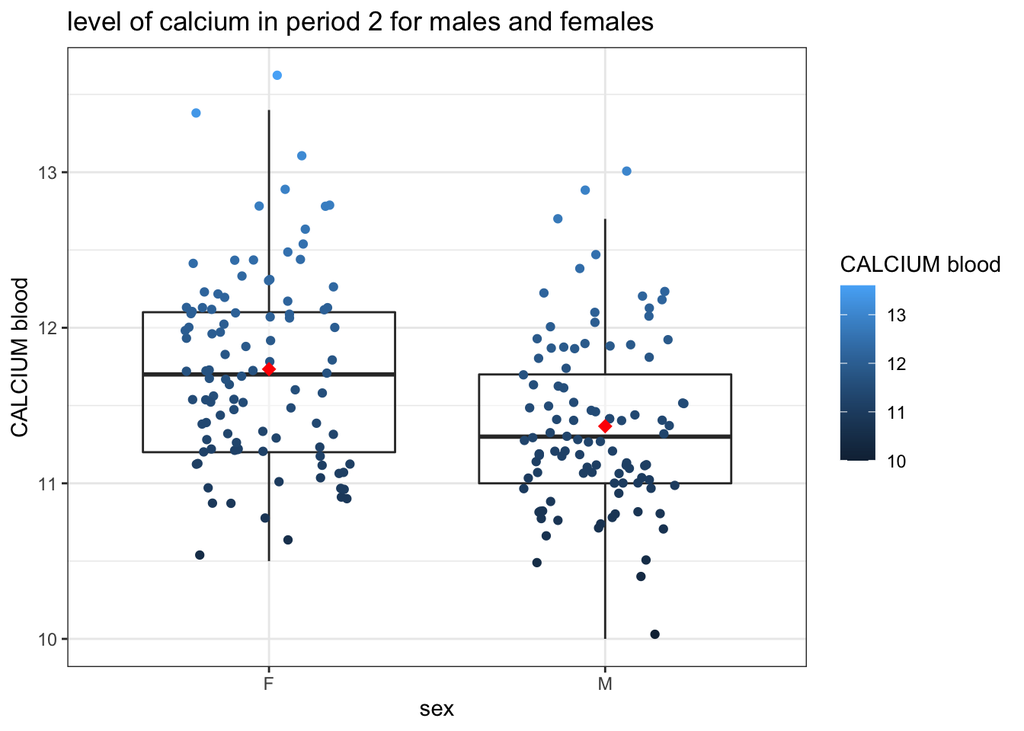

```r
# plot the calcium level of period 2 for males and females

MON810_clean <- MON810 %>% filter (!is.na(`CALCIUM blood`))

MON810_clean %>% filter (period == 2) %>%
  ggplot(aes(x=sex, y=`CALCIUM blood`, colour=`CALCIUM blood`, fill=`CALCIUM blood`)) +
  geom_boxplot(alpha=0.5, outlier.alpha=0) +
    geom_jitter(width=0.25) +
    stat_summary(fun=mean, colour="red", geom="point",shape=18, size=3) + #red point is the mean
  xlab("sex") +
  ylab("CALCIUM blood") +
  ggtitle('level of calcium in period 2 for males and females') +
  theme_bw()
```

### Question 1

Assume normal distribution for CALCIUM level in blood, we can perform student test.

```r
alpha <- 0.05
x <- MON810_clean %>% filter (period == 2 & sex == 'F') %>% pull("CALCIUM blood")
y <- MON810_clean %>% filter (period == 2 & sex == 'M') %>% pull("CALCIUM blood")
cat('Variance of x is ', var(x), '\n')
```

```
## Variance of x is  0.3699434
```

```r
cat('Variance of y is ', var(y), '\n')
```

```
## Variance of y is  0.2953646
```

```r
# we assume different variance, based on the variance of samples
t.test(x, y, conf.level = 1-alpha, var.equal = FALSE)
```

```
##
##  Welch Two Sample t-test
##
## data:  x and y
## t = 4.4994, df = 195.54, p-value = 1.168e-05
## alternative hypothesis: true difference in means is not equal to 0
## 95 percent confidence interval:
##  0.2061372 0.5278628
## sample estimates:
## mean of x mean of y
##    11.734    11.367
```

The p-value is quite small. We reject the null hypothesis. At level alpha=0.05, we could not prove that the mean level of calcium for period 2 is the same for males and females. It could also be observed in the figure above.

2. test for the males if the mean level of calcium is the same for period 1 and period 2.

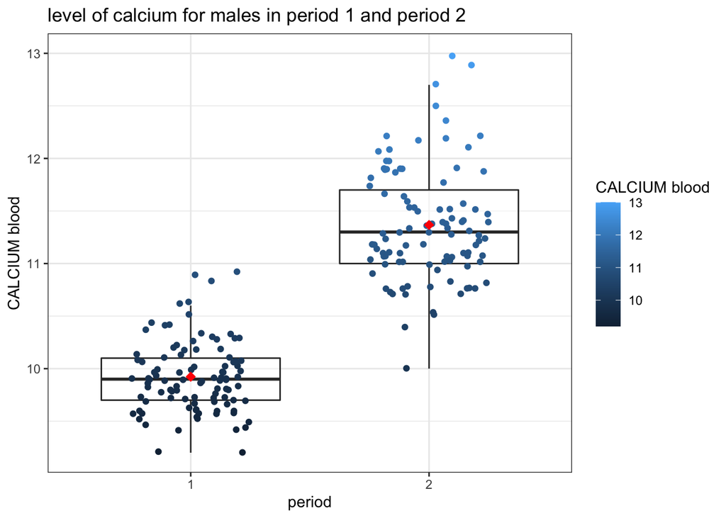

```r
MON810_clean %>% filter (sex == 'M') %>%
  ggplot(aes(x=as.factor(period), y=`CALCIUM blood`, colour=`CALCIUM blood`, fill=`CALCIUM blood`)) +
  geom_boxplot(alpha=0.5, outlier.alpha=0) +
    geom_jitter(width=0.25) +
    stat_summary(fun=mean, colour="red", geom="point",shape=18, size=3) + #red point is the mean
  xlab("period") +
  ylab("CALCIUM blood") +
  ggtitle('level of calcium for males in period 1 and period 2') +
  theme_bw()
```

```r
alpha <- 0.05
x <- MON810_clean %>% filter (period == 1 & sex == 'M') %>% pull("CALCIUM blood")
y <- MON810_clean %>% filter (period == 2 & sex == 'M') %>% pull("CALCIUM blood")
cat('Variance of x is ', var(x), '\n')
```

```
## Variance of x is  0.1135061
```

```r
cat('Variance of y is ', var(y), '\n')
```

```
## Variance of y is  0.2953646
```

```r
# we assume different variance, based on the variance of samples
t.test(x, y, conf.level = 1-alpha, var.equal = FALSE)
```

```
##
##  Welch Two Sample t-test
##
## data:  x and y
## t = -22.583, df = 165.3, p-value < 2.2e-16
## alternative hypothesis: true difference in means is not equal to 0
## 95 percent confidence interval:
##  -1.57025 -1.31775
## sample estimates:
## mean of x mean of y
##     9.923    11.367
```

### Question 2

We can reject the null hypothesis. At level alpha=0.05, we could not prove that for the males if the mean level of calcium is the same for period 1 and period 2.

3. test for the males if the mean level of calcium for period 2 is the same for the control group and the MON810 group.

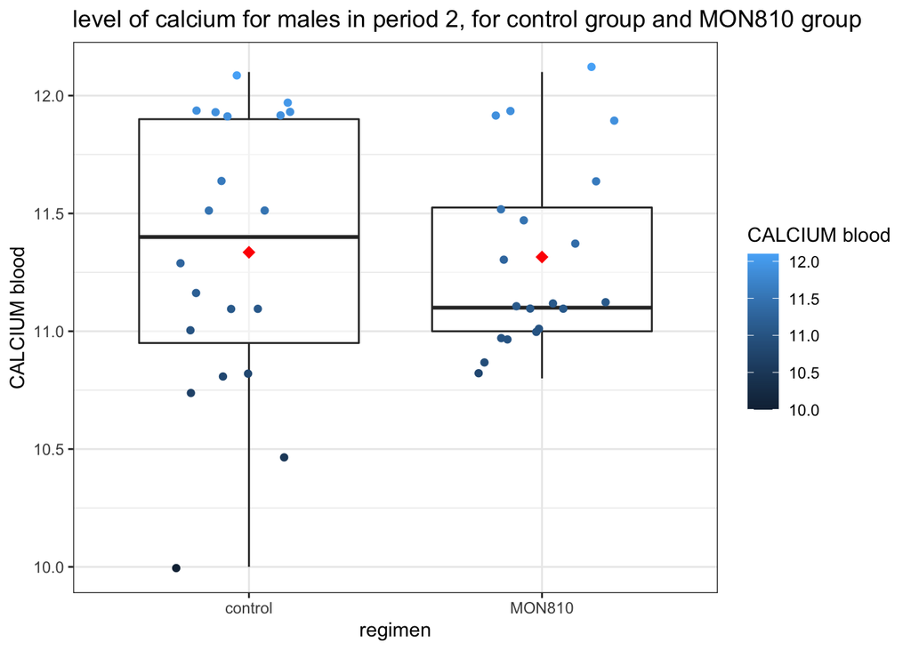

```r
MON810_clean %>% filter (sex == 'M' & period == 2 & (regimen == 'control' | regimen == 'MON810')) %>%
  ggplot(aes(x=regimen, y=`CALCIUM blood`, colour=`CALCIUM blood`, fill=`CALCIUM blood`)) +
  geom_boxplot(alpha=0.5, outlier.alpha=0) +
    geom_jitter(width=0.25) +
    stat_summary(fun=mean, colour="red", geom="point",shape=18, size=3) + #red point is the mean
  xlab("regimen") +
  ylab("CALCIUM blood") +
  ggtitle('level of calcium for males in period 2, for control group and MON810 group') +
  theme_bw()
```

```r
alpha <- 0.05
x <- MON810_clean %>% filter (period == 2 & sex == 'M' & regimen == 'control') %>% pull("CALCIUM blood")
y <- MON810_clean %>% filter (period == 2 & sex == 'M' & regimen == 'MON810') %>% pull("CALCIUM blood")
cat('Variance of x is ', var(x), '\n')
```

```
## Variance of x is  0.3392368
```

```r
cat('Variance of y is ', var(y), '\n')
```

```
## Variance of y is  0.1508158
```

```r
# we assume different variance, based on the variance of samples
t.test(x, y, conf.level = 1-alpha, var.equal = FALSE)
```

```
##
##  Welch Two Sample t-test
##
## data:  x and y
## t = 0.12777, df = 33.106, p-value = 0.8991
## alternative hypothesis: true difference in means is not equal to 0
## 95 percent confidence interval:
##  -0.2984304  0.3384304
## sample estimates:
## mean of x mean of y
##    11.335    11.315
```

### Question 3

The p-value is quite big. At level alpha=0.05, we could say that the mean level of calcium in period 2 for the males is the same for the control group and the MON810 group.

4. What is the probability to detect a difference of one standard deviation (1 sd) with only 10 animals per group? with 20 animal? How can we ensure to detect such difference with a probability of 80%?

```r
alpha <- 0.05
pwr.t.test(n = 10, d = 1, type = "two.sample",
           alternative="two.sided", sig.level = alpha)
```

```
##
##      Two-sample t test power calculation
##
##               n = 10
##               d = 1
##       sig.level = 0.05
##           power = 0.5620066
##     alternative = two.sided
##
## NOTE: n is number in *each* group
```

```r
pwr.t.test(n = 20, d = 1, type = "two.sample",
           alternative="two.sided", sig.level = alpha)
```

```
##
##      Two-sample t test power calculation
##
##               n = 20
##               d = 1
##       sig.level = 0.05
##           power = 0.868953
##     alternative = two.sided
##
## NOTE: n is number in *each* group
```

```r
pwr.t.test(power = 0.8, d = 1, sig.level=alpha)
```

```
##
##      Two-sample t test power calculation
##
##               n = 16.71472
##               d = 1
##       sig.level = 0.05
##           power = 0.8
##     alternative = two.sided
##
## NOTE: n is number in *each* group
```

### Question 4

Conclusion: The probability to detect a difference of one standard deviation with 10 animals per group is 0.56; with 20 animal, the probability is 0.87 To detect such difference with a probability of 80%, we need 17 animals per group (ceil(16.7) = 17).

## Multiple comparisons

1. Redo the three tests of the previous section (questions 1-3) for now comparing the means of all the quantitative variables. Store the results (the p-values) in a data frame with one variable per row and four columns (name of the variable + three p-values).

```r
do_all_comparisons <- function(data, alpha) {
  map(colnames(MON810_clean)[5:51],
    function(col) {
    # question 1
    males <- filter(data, period == 2 & sex == 'M') %>% pull(col)
    females <- filter(data, period == 2 & sex == 'F') %>% pull(col)
    t1 <- t.test(males, females, conf.level = 1-alpha, var.equal = FALSE)
    # question 2
    period1 <- filter(data, period == 1 & sex == 'M') %>% pull(col)
    period2 <- filter(data, period == 2 & sex == 'M') %>% pull(col)
    t2 <- t.test(period1, period2, conf.level = 1-alpha, var.equal = FALSE)
    # question 3
    control <- filter (data, period == 2 & sex == 'M' & regimen == 'control') %>% pull(col)
    g_MON810 <- filter (data, period == 2 & sex == 'M' & regimen == 'MON810') %>% pull(col)
    t3 <- t.test(control, g_MON810, conf.level = 1-alpha, var.equal = FALSE)
    data.frame(
      Variable    = col,
      p.value_q1    = t1$p.value,
      p.value_q2    = t2$p.value,
      p.value_q3    = t3$p.value
    )
  }) %>% bind_rows()
}

all_comparisons <- do_all_comparisons(MON810_clean, alpha = 0.05)
all_comparisons %>% rmarkdown::paged_table()
```

| Variable | p.value_q1 | p.value_q2 | p.value_q3 |
| --- | --- | --- | --- |
| ALBUMIN | 2.671973e-37 | 6.198082e-10 | 0.92670046 |
| ALKPHOSPH | 7.640668e-40 | 3.566211e-34 | 0.77971357 |
| SGPTALT | 3.934480e-03 | 7.441839e-02 | 0.84976243 |
| SGOTAST | 1.746933e-03 | 2.997316e-12 | 0.62083866 |
| BUN | 7.669199e-11 | 2.511871e-14 | 0.58396754 |
| CALCIUM blood | 1.167924e-05 | 2.168533e-52 | 0.89910519 |
| CREAT blood | 2.048889e-10 | 3.090504e-58 | 1.00000000 |
| Glycemia | 1.670859e-15 | 8.184426e-65 | 0.90483362 |
| PHOSPH blood | 3.393853e-03 | 9.496858e-37 | 0.39177006 |
| TOTPROT | 1.514556e-21 | 4.769457e-21 | 0.27831950 |

[output cut: 37 more lines]

2. For each of the three tests, adjust the p-values using the Bonferroni and the Benjamini-Hochberg corrections. How can we interpret these results?

```r
m <- nrow(all_comparisons)
all_comparisons$p.value_bonferonni_q1 <- pmin(1, all_comparisons$p.value_q1 * m)
all_comparisons$p.value_bonferonni_q2 <- pmin(1, all_comparisons$p.value_q2 * m)
all_comparisons$p.value_bonferonni_q3 <- pmin(1, all_comparisons$p.value_q3 * m)
all_comparisons$p.bh_q1 <- p.adjust(all_comparisons$p.value_q1, method = "BH")
all_comparisons$p.bh_q2 <- p.adjust(all_comparisons$p.value_q2, method = "BH")
all_comparisons$p.bh_q3 <- p.adjust(all_comparisons$p.value_q3, method = "BH")
all_comparisons %>% rmarkdown::paged_table()
```

| Variable | p.value_q1 | p.value_q2 | p.value_q3 | p.value_bonferonni_q1 | p.value_bonferonni_q2 | p.value_bonferonni_q3 | p.bh_q1 | p.bh_q2 | p.bh_q3 |
| --- | --- | --- | --- | --- | --- | --- | --- | --- | --- |
| ALBUMIN | 2.671973e-37 | 6.198082e-10 | 0.92670046 | 1.255827e-35 | 2.913098e-08 | 1 | 6.279136e-36 | 1.165239e-09 | 0.9899046 |
| ALKPHOSPH | 7.640668e-40 | 3.566211e-34 | 0.77971357 | 3.591114e-38 | 1.676119e-32 | 1 | 3.591114e-38 | 2.793532e-33 | 0.9846383 |
| SGPTALT | 3.934480e-03 | 7.441839e-02 | 0.84976243 | 1.849205e-01 | 1.000000e+00 | 1 | 5.778767e-03 | 8.744161e-02 | 0.9899046 |
| SGOTAST | 1.746933e-03 | 2.997316e-12 | 0.62083866 | 8.210586e-02 | 1.408739e-10 | 1 | 2.831236e-03 | 6.708279e-12 | 0.9846383 |
| BUN | 7.669199e-11 | 2.511871e-14 | 0.58396754 | 3.604523e-09 | 1.180579e-12 | 1 | 2.772710e-10 | 6.213576e-14 | 0.9846383 |
| CALCIUM blood | 1.167924e-05 | 2.168533e-52 | 0.89910519 | 5.489244e-04 | 1.019210e-50 | 1 | 2.195697e-05 | 3.397368e-51 | 0.9899046 |
| CREAT blood | 2.048889e-10 | 3.090504e-58 | 1.00000000 | 9.629780e-09 | 1.452537e-56 | 1 | 6.878414e-10 | 7.262685e-57 | 1.0000000 |
| Glycemia | 1.670859e-15 | 8.184426e-65 | 0.90483362 | 7.853039e-14 | 3.846680e-63 | 1 | 7.853039e-15 | 3.846680e-63 | 0.9899046 |
| PHOSPH blood | 3.393853e-03 | 9.496858e-37 | 0.39177006 | 1.595111e-01 | 4.463523e-35 | 1 | 5.145519e-03 | 8.927046e-36 | 0.9846383 |
| TOTPROT | 1.514556e-21 | 4.769457e-21 | 0.27831950 | 7.118413e-20 | 2.241645e-19 | 1 | 1.423683e-20 | 2.241645e-20 | 0.9846383 |

[output cut: 37 more lines]

# Linear models: quarterly sales volumes

## Fitting a linear model

The file `sales1.csv` consists of quarterly sales volumes (in % and indexed to the time 0) of a product.

```r
sales1 <- readr::read_csv("sales1.csv", show_col_types = FALSE)
rmarkdown::paged_table(sales1)
```

| time | y |
| --- | --- |
| 1 | 101.82562 |
| 4 | 103.16069 |
| 7 | 99.48002 |
| 10 | 103.25016 |
| 13 | 106.46870 |
| 16 | 108.53795 |
| 19 | 104.75776 |
| 22 | 106.77594 |
| 25 | 109.89066 |
| 28 | 112.05444 |

[output cut: 11 more lines]

1. Plot the data and comment.

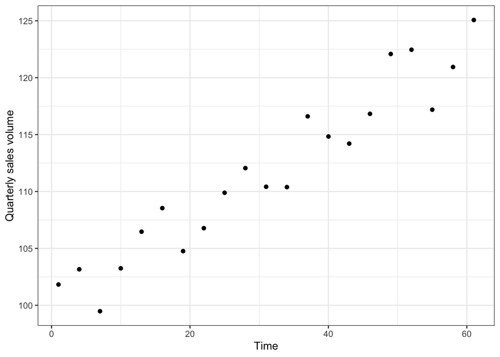

```r
sales1_plot <- ggplot(data = sales1, aes(x = time, y = y)) +
  geom_point() +
  xlab("Time") +
  ylab("Quarterly sales volume") +
  theme_bw()
sales1_plot
```

### Question 1

It seems that the sales volume increases with the time. We can try a linear model to fit it.

2. Fit a polynomial model to this data (justify the choice of the degree). What do the residuals suggest?

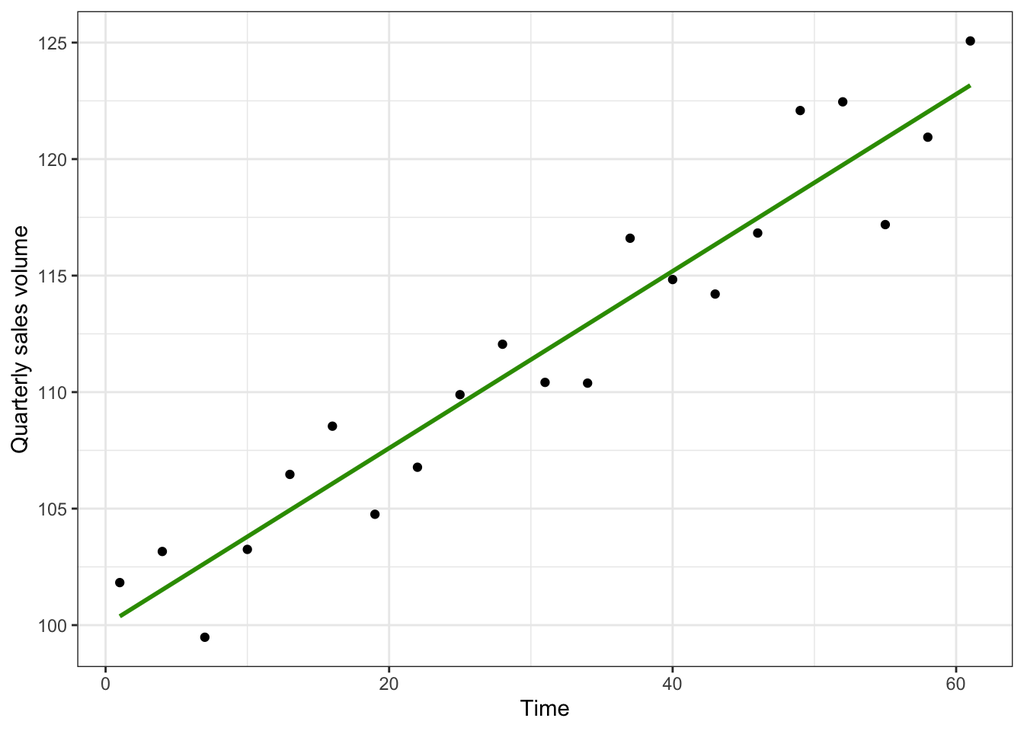

```r
sales1_plot + geom_smooth(method = "lm", formula = y ~ x, se = FALSE, colour="#339900")
```

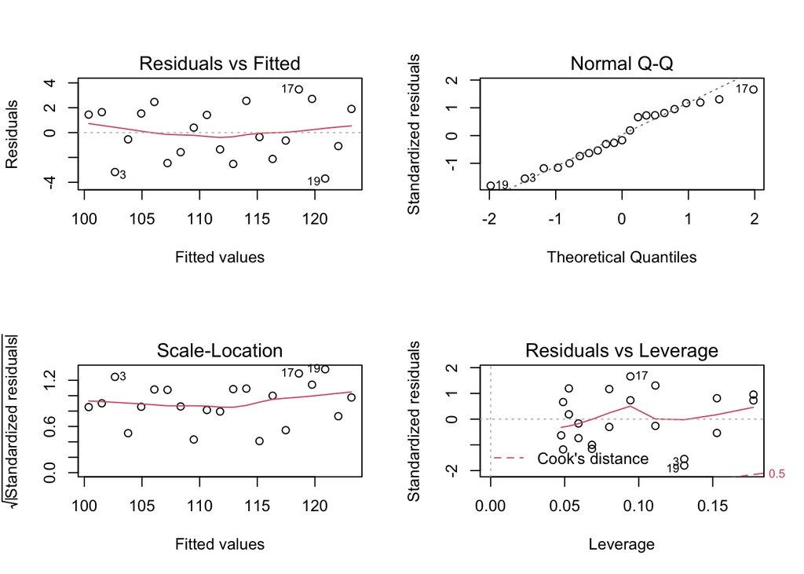

```r
model1 <- lm(y~time, data=sales1)
par(mfrow=c(2,2))
plot(model1)
```

```r
summary(model1)
```

```
##
## Call:
## lm(formula = y ~ time, data = sales1)
##
## Residuals:
##     Min      1Q  Median      3Q     Max
## -3.6994 -1.5777 -0.3596  1.6444  3.4747
##
## Coefficients:
##              Estimate Std. Error t value Pr(>|t|)
## (Intercept)  99.99688    0.94971  105.29  < 2e-16 ***
## time          0.37985    0.02643   14.37 1.17e-11 ***
## ---
## Signif. codes:  0 '***' 0.001 '**' 0.01 '*' 0.05 '.' 0.1 ' ' 1
##
## Residual standard error: 2.2 on 19 degrees of freedom
## Multiple R-squared:  0.9158, Adjusted R-squared:  0.9113
## F-statistic: 206.5 on 1 and 19 DF,  p-value: 1.166e-11
```

### Question 2

We choose polynomial model with degree 1, because the plot shows the linear relation between time and sales volume. Those 4 figures show that the residuals are centered gaussian, have homosedasctic variance, which corresponds well with the assumptions of gaussian linear regression. But the Residual standard error in summary shows that the residuals are relatively big. We can try to fit a better model.

3. Try to improve the model by adding a periodic component. Write your final model as a mathematical equation.

### Hints

- $\cos(2\pi t/T)$ and $\sin(2\pi t/T)$ are periodic functions of period $T$.
- One can easily deduce the period $T$ from the context and looking at the data.

### Question 3

4. Plot on a same graph the observed sales together with the predicted sales given by your final model. What do you think about this model? What about the residuals?

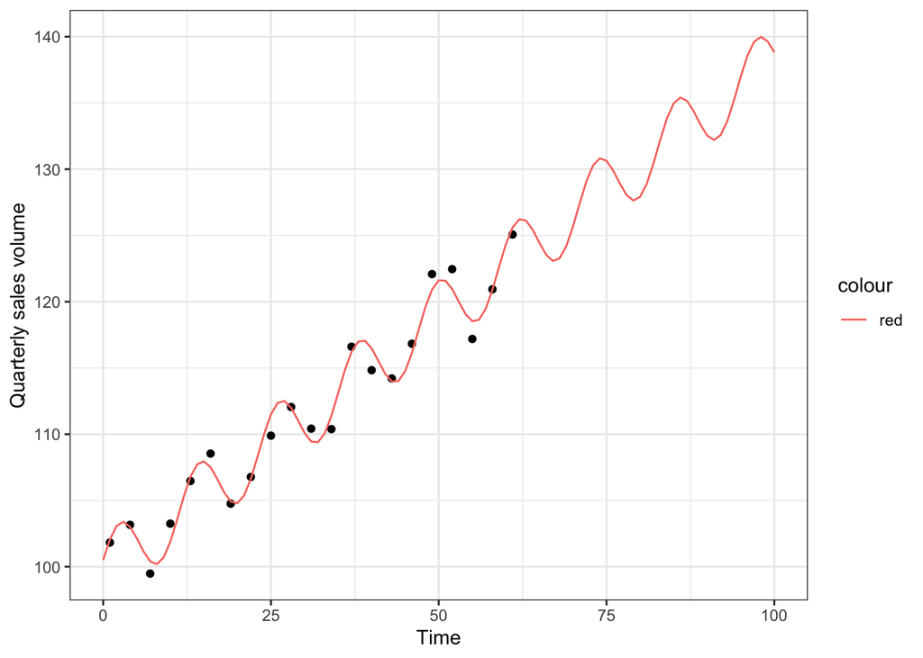

```r
# nlm model
nlm1 <- nls(y ~ k*time + b + A*cos(time*2*pi/T + phi), sales1,
            start = c(k=0.3, b=100, A=5, T=10, phi=1))

pred_time <- data.frame(time = seq(0, 100, by=1))
pred_sales <- predict(nlm1, newdata=pred_time)
prediction1 <- pred_time %>% mutate(sales=pred_sales)

sales1_plot +
  geom_line(data = prediction1, aes(x = time, y = sales, colour="red"))
```

```r
summary(nlm1)
```

```
##
## Formula: y ~ k * time + b + A * cos(time * 2 * pi/T + phi)
##
## Parameters:
##     Estimate Std. Error t value Pr(>|t|)
## k     0.3850     0.0128  30.080 1.64e-15 ***
## b    99.7191     0.4566 218.392  < 2e-16 ***
## A     2.6464     0.3226   8.202 4.00e-07 ***
## T    11.8838     0.1578  75.311  < 2e-16 ***
## phi   5.0144     0.2464  20.355 7.29e-13 ***
## ---
## Signif. codes:  0 '***' 0.001 '**' 0.01 '*' 0.05 '.' 0.1 ' ' 1
##
## Residual standard error: 1.05 on 16 degrees of freedom
##
## Number of iterations to convergence: 11
## Achieved convergence tolerance: 2.627e-06
```

### Question 4

This modified model represents well the periodic property of sales volume. Regarding the residuals, they are in average smaller compared to the previous linear model (1.05 compared to 2.2).

5. We want the predicted sales volume to be equal to 100 at time 0. Modify your final model in order to take this constraint into account.

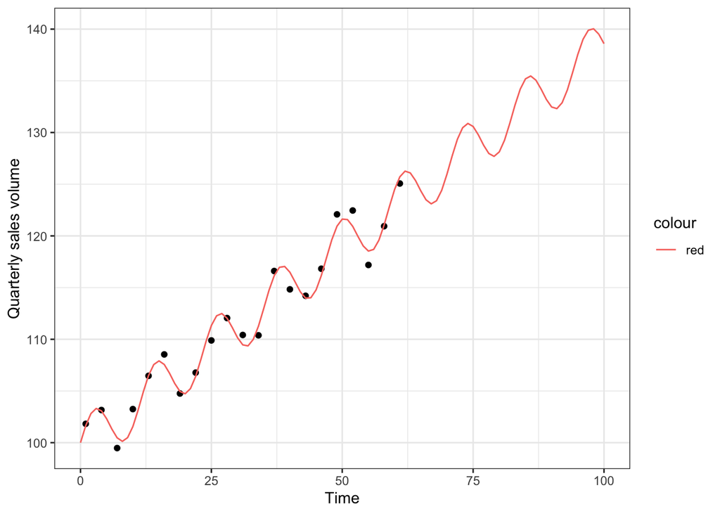

```r
nlm2 <- nls(y ~ k*time + A*(cos(time*2*pi/T + phi) - cos(phi)) + 100, sales1,
            start = c(k=0.3, A=5, T=11, phi=5))

pred_time <- data.frame(time = seq(0, 100, by=1))
pred_sales2 <- predict(nlm2, newdata=pred_time)
prediction2 <- pred_time %>% mutate(sales=pred_sales2)

sales1_plot +
  geom_line(data = prediction2, aes(x = time, y = sales, colour="red"))
```

```r
summary(nlm2)
```

```
##
## Formula: y ~ k * time + A * (cos(time * 2 * pi/T + phi) - cos(phi)) +
##     100
##
## Parameters:
##     Estimate Std. Error t value Pr(>|t|)
## k    0.38872    0.01135  34.249  < 2e-16 ***
## A    2.63995    0.31791   8.304 2.19e-07 ***
## T   11.81641    0.11443 103.263  < 2e-16 ***
## phi  4.88254    0.14499  33.675  < 2e-16 ***
## ---
## Signif. codes:  0 '***' 0.001 '**' 0.01 '*' 0.05 '.' 0.1 ' ' 1
##
## Residual standard error: 1.033 on 17 degrees of freedom
##
## Number of iterations to convergence: 10
## Achieved convergence tolerance: 1.577e-06
```

### Question 5

The final model is:
$$y = k*time + A*(cos(2*pi*time/T + phi) - cos(phi)) + 100$$

## Fitting a linear mixed effects model

The file `sales30.csv` now consists of quarterly sales volumes (still in % and indexed to the time 0) of 30 different products.

```r
sales30 <- readr::read_csv("sales30.csv", show_col_types = FALSE) %>% mutate(id = as.factor(id))
rmarkdown::paged_table(sales30)
```

| id | time | y |
| --- | --- | --- |
| 1 | 1 | 101.82562 |
| 1 | 4 | 103.16069 |
| 1 | 7 | 99.48002 |
| 1 | 10 | 103.25016 |
| 1 | 13 | 106.46870 |
| 1 | 16 | 108.53795 |
| 1 | 19 | 104.75776 |
| 1 | 22 | 106.77594 |
| 1 | 25 | 109.89066 |
| 1 | 28 | 112.05444 |

[output cut: 620 more lines]

1. Plot the data and comment

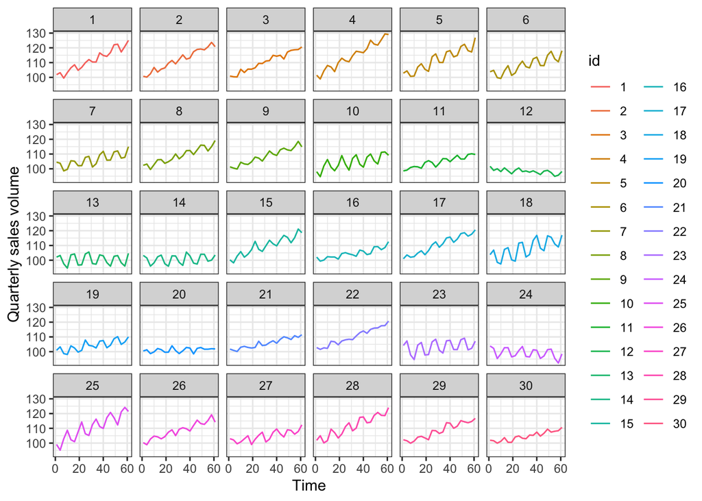

```r
sales30_plot <- ggplot(data = sales30, aes(x = time, y = y, color=id)) +
  geom_line() + facet_wrap(~id) +
  xlab("Time") +
  ylab("Quarterly sales volume") +
  theme_bw()
sales30_plot
```

### Question 1 Comment: We find that for most products, the trend of sales volumes over time is similar to the previous case. But there are also several products whose sales volume is almost constant with a little fluctuations. For instance, products with id=12,13,14.

2. Adjust the model used previously for fitting the first series to this data and comment the results.

```r
nlm30_1 <- nls(y ~ k*time + b + A*cos(time*2*pi/T + phi), sales30,
            start = c(k=0.2, b=100, A=5, T=11, phi=1))
summary(nlm30_1)
```

```
##
## Formula: y ~ k * time + b + A * cos(time * 2 * pi/T + phi)
##
## Parameters:
##      Estimate Std. Error t value Pr(>|t|)
## k     0.21690    0.01191  18.216  < 2e-16 ***
## b   100.08971    0.42554 235.205  < 2e-16 ***
## A    -1.53703    0.29878  -5.144 3.60e-07 ***
## T    12.07923    0.26673  45.286  < 2e-16 ***
## phi   2.29922    0.40917   5.619 2.89e-08 ***
## ---
## Signif. codes:  0 '***' 0.001 '**' 0.01 '*' 0.05 '.' 0.1 ' ' 1
##
## Residual standard error: 5.364 on 625 degrees of freedom
##
## Number of iterations to convergence: 6
## Achieved convergence tolerance: 8.125e-06
```

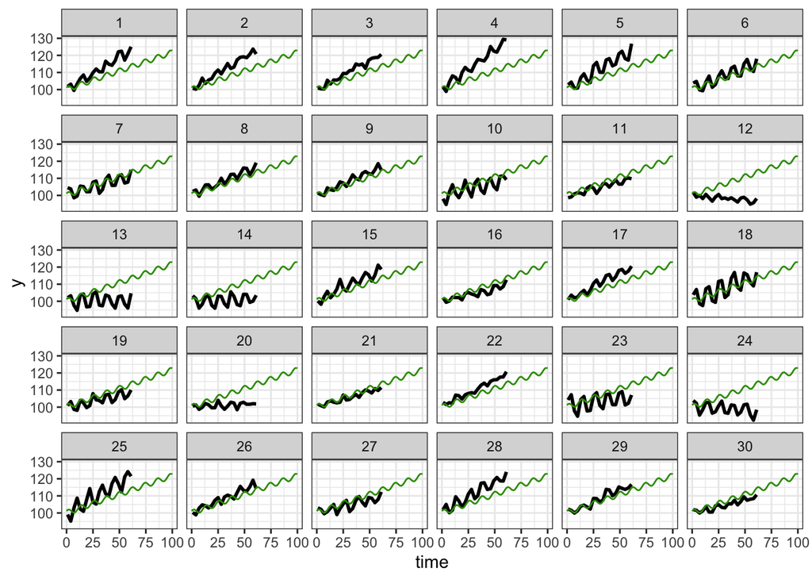

```r
pred_time <- data.frame(time = seq(0, 100, by=1))
pred_sales30_1 <- predict(nlm30_1, newdata=pred_time)
prediction30_1 <- pred_time %>% mutate(sales=pred_sales30_1)

ggplot(data = sales30, aes(x = time, y = y)) +
  geom_line(size=1) + facet_wrap(~id) +
  theme_bw() +
  geom_line(data = prediction30_1, aes(x = time, y = sales), colour='#339900')
```

### Question 2

The green line is the fitted model. In some cases, it can reflect the general trend. But in some extreme cases, for instance, id=12,13,14, there is a big gap between the true value and predicted value. Therefore, we need to consider the random effect for each product.

3. Fit a mixed effect model to this data (discuss the choice of fixed and random effects). Write your final model as a mathematical equation.

```r
saemix_data <- saemixData(name.data       = sales30,
                          name.group      = "id",
                          name.predictors = "time",
                          name.response   = "y")
```

```
## Using the object called sales30 in this R session as the data.
##
##
## The following SaemixData object was successfully created:
##
## Object of class SaemixData
##     longitudinal data for use with the SAEM algorithm
## Dataset sales30
##     Structured data: y ~ time | id
##     Predictor: time ()
```

```r
model1_nlme <- function(psi,id,x) {
  t   <- x[,1]
  k  <- psi[id,1]
  A   <- psi[id,2]
  b  <- psi[id,3]
  T <-psi[id,4]
  phi <- psi[id,5]
  fpred <- k*t + b + A*cos(t*2*pi/T + phi)
  fpred
}

saemix_model1 <- saemixModel(model = model1_nlme,
                            psi0  = c(k=0.3,A=2,b=100,T=11,phi=1))
```

```
## Warning: psi0 given as a vector, reshaping it to a matrix.
##
##
## The following SaemixModel object was successfully created:
##
## Nonlinear mixed-effects model
##   Model function
## function(psi,id,x) {
##   t   <- x[,1]
##   k  <- psi[id,1]
##   A   <- psi[id,2]
##   b  <- psi[id,3]
##   T <-psi[id,4]
##   phi <- psi[id,5]
##   fpred <- k*t + b + A*cos(t*2*pi/T + phi)
##   fpred
## }
##   Nb of parameters: 5
##       parameter names:  k A b T phi
##       distribution:
##      Parameter Distribution Estimated
## [1,] k         normal       Estimated
## [2,] A         normal       Estimated
## [3,] b         normal       Estimated
## [4,] T         normal       Estimated
## [5,] phi       normal       Estimated
##   Variance-covariance matrix:
##     k A b T phi
## k   1 0 0 0   0
## A   0 1 0 0   0
## b   0 0 1 0   0
## T   0 0 0 1   0
## phi 0 0 0 0   1
##   Error model: constant , initial values: a.=1
##     No covariate in the model.
##     Initial values
##                k A   b  T phi
## Pop.CondInit 0.3 2 100 11   1
```

```r
saemix_options <- list(map=TRUE, fim=TRUE, ll.is=FALSE, displayProgress=FALSE, save=FALSE, seed=632544)
saemix_fit1    <- saemix(saemix_model1, saemix_data, saemix_options)
```

```
## Nonlinear mixed-effects model fit by the SAEM algorithm
## -----------------------------------
## ----          Data             ----
## -----------------------------------
## Object of class SaemixData
##     longitudinal data for use with the SAEM algorithm
## Dataset sales30
##     Structured data: y ~ time | id
##     Predictor: time ()
## Dataset characteristics:
##     number of subjects:     30
##     number of observations: 630
##     average/min/max nb obs: 21.00  /  21  /  21
## First 10 lines of data:
##    id time         y mdv cens occ ytype
## 1   1    1 101.82562   0    0   1     1
## 2   1    4 103.16069   0    0   1     1
## 3   1    7  99.48002   0    0   1     1
## 4   1   10 103.25016   0    0   1     1
## 5   1   13 106.46870   0    0   1     1
## 6   1   16 108.53795   0    0   1     1
## 7   1   19 104.75776   0    0   1     1
## 8   1   22 106.77594   0    0   1     1
## 9   1   25 109.89066   0    0   1     1
## 10  1   28 112.05444   0    0   1     1
## -----------------------------------
## ----          Model            ----
## -----------------------------------
## Nonlinear mixed-effects model
##   Model function
## function(psi,id,x) {
##   t   <- x[,1]
##   k  <- psi[id,1]
##   A   <- psi[id,2]
##   b  <- psi[id,3]
##   T <-psi[id,4]
##   phi <- psi[id,5]
##   fpred <- k*t + b + A*cos(t*2*pi/T + phi)
##   fpred
## }
```

[output cut: 61 more lines]

```
##            omega2.k omega2.A omega2.b omega2.T omega2.phi
## omega2.k   1        0        0        0        0
## omega2.A   0        1        0        0        0
## omega2.b   0        0        1        0        0
## omega2.T   0        0        0        1        0
## omega2.phi 0        0        0        0        1
## ----------------------------------------------------
## ---------------  Statistical criteria  -------------
## ----------------------------------------------------
## Likelihood computed by linearisation
##       -2LL= 3631.832
##       AIC = 3653.832
##       BIC = 3669.245
## ----------------------------------------------------
## Plotting the data
```

```
## Plotting convergence plots
```

```
## Plotting observations versus predictions
```

```
## Plotting individual fits
```

### Question 3

We have to consider the random effect for all parameters. Because the plot of different products is quite different. Even the intercept is not the same.

The mixed effect model is:
$$y_{ij} = f(t_{ij}, \psi_{i}) + \epsilon_{ij} \\where\ \psi_{i} = (k_{i}, A_{i}, b_{i}, T_{i}, phi_{i}) \\ f(t,\psi) = k*t + b + A*cos(t*2*pi/T + phi) \\for\ i = 1...N, j = 1...n_{i}$$
N is the number of products. n_i is the number of measurements for product i.

4. Plot the data with the predicted sales given by the chosen model.

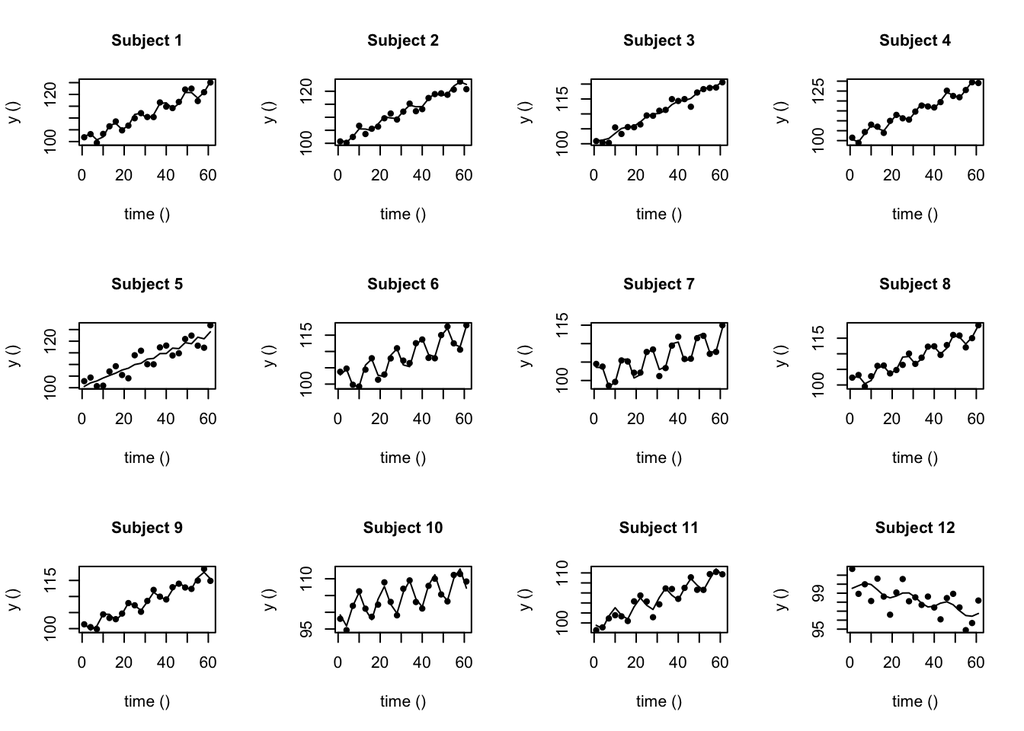

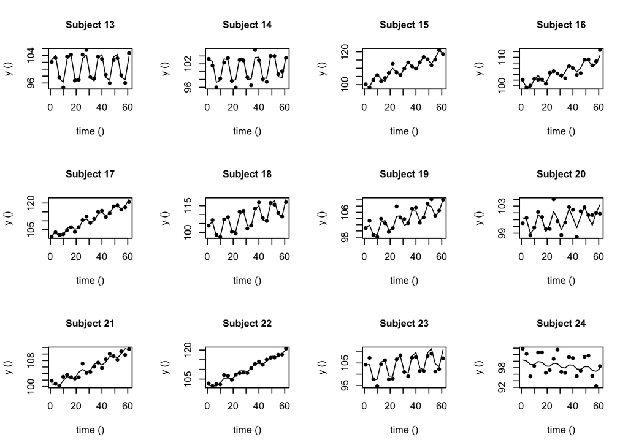

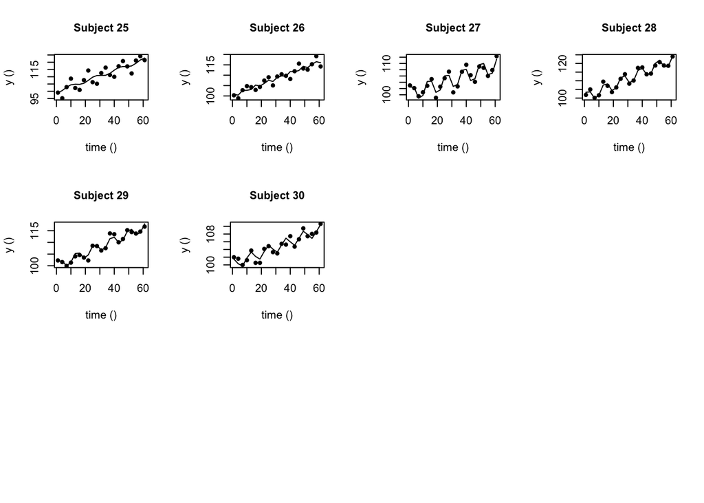

```r
saemix.plot.fits(saemix_fit1)
```

5. Modify the previous model to take into account the previous constraint (predicted sales volume are all equal to 100 at time 0).

```r
model2_nlme <- function(psi,id,x) {
  t   <- x[,1]
  k  <- psi[id,1]
  A   <- psi[id,2]
  T <-psi[id,3]
  phi <- psi[id,4]
  fpred <- k*t + A*(cos(t*2*pi/T + phi) - cos(phi)) + 100
  fpred
}

saemix_model2 <- saemixModel(model = model2_nlme,
                            psi0  = c(k=0.3,A=2,T=11,phi=1))
```

```
## Warning: psi0 given as a vector, reshaping it to a matrix.
##
##
## The following SaemixModel object was successfully created:
##
## Nonlinear mixed-effects model
##   Model function
## function(psi,id,x) {
##   t   <- x[,1]
##   k  <- psi[id,1]
##   A   <- psi[id,2]
##   T <-psi[id,3]
##   phi <- psi[id,4]
##   fpred <- k*t + A*(cos(t*2*pi/T + phi) - cos(phi)) + 100
##   fpred
## }
##   Nb of parameters: 4
##       parameter names:  k A T phi
##       distribution:
##      Parameter Distribution Estimated
## [1,] k         normal       Estimated
## [2,] A         normal       Estimated
## [3,] T         normal       Estimated
## [4,] phi       normal       Estimated
##   Variance-covariance matrix:
##     k A T phi
## k   1 0 0   0
## A   0 1 0   0
## T   0 0 1   0
## phi 0 0 0   1
##   Error model: constant , initial values: a.=1
##     No covariate in the model.
##     Initial values
##                k A  T phi
## Pop.CondInit 0.3 2 11   1
```

```r
saemix_fit2 <- saemix(saemix_model2, saemix_data, saemix_options)
```

```
## Nonlinear mixed-effects model fit by the SAEM algorithm
## -----------------------------------
## ----          Data             ----
## -----------------------------------
## Object of class SaemixData
##     longitudinal data for use with the SAEM algorithm
## Dataset sales30
##     Structured data: y ~ time | id
##     Predictor: time ()
## Dataset characteristics:
##     number of subjects:     30
##     number of observations: 630
##     average/min/max nb obs: 21.00  /  21  /  21
## First 10 lines of data:
##    id time         y mdv cens occ ytype
## 1   1    1 101.82562   0    0   1     1
## 2   1    4 103.16069   0    0   1     1
## 3   1    7  99.48002   0    0   1     1
## 4   1   10 103.25016   0    0   1     1
## 5   1   13 106.46870   0    0   1     1
## 6   1   16 108.53795   0    0   1     1
## 7   1   19 104.75776   0    0   1     1
## 8   1   22 106.77594   0    0   1     1
## 9   1   25 109.89066   0    0   1     1
## 10  1   28 112.05444   0    0   1     1
## -----------------------------------
## ----          Model            ----
## -----------------------------------
## Nonlinear mixed-effects model
##   Model function
## function(psi,id,x) {
##   t   <- x[,1]
##   k  <- psi[id,1]
##   A   <- psi[id,2]
##   T <-psi[id,3]
##   phi <- psi[id,4]
##   fpred <- k*t + A*(cos(t*2*pi/T + phi) - cos(phi)) + 100
##   fpred
## }
## <bytecode: 0x7fa2d1d59080>
```

[output cut: 55 more lines]

```
## ----------------------------------------------------
##            omega2.k omega2.A omega2.T omega2.phi
## omega2.k   1        0        0        0
## omega2.A   0        1        0        0
## omega2.T   0        0        1        0
## omega2.phi 0        0        0        1
## ----------------------------------------------------
## ---------------  Statistical criteria  -------------
## ----------------------------------------------------
## Likelihood computed by linearisation
##       -2LL= 4294.298
##       AIC = 4312.298
##       BIC = 4324.909
## ----------------------------------------------------
## Plotting the data
```

```
## Plotting convergence plots
```

```
## Plotting observations versus predictions
```

```
## Plotting individual fits
```